# MBTA: Which Line Should You Trust

Hadear Rizq

5/6/26

```r
# Load any R Packages you may need
library(tidyverse)
library(tidytext)
library(caret)
library(pROC)
library(rpart)
library(rpart.plot)
library(partykit)
library(mosaic)
```

```r
mbta = read.csv("MBTA_Reliability.csv")
```

# Introduction

**Research Question:** Which rapid transit line is the most reliable and what factors(line,year,peak/off-peak) best predict that reliability?

Every day, hundreds of thousands of Bostonians depend on the Massachusetts Bay Transportation Authority (MBTA) to get to work, school, and appointments on time. Yet many riders wonder: “Will I reach my destination on time?” This uncertainty affects commute planning and quality of life for people who rely on public transportation.

The MBTA’s rapid transit system consists of four main lines: Red Line, Green Line, Orange Line, and Blue Line. The key metric the MBTA uses to measure reliability is **On Time Performance (OTP)**, which represents the proportion f trips that arrive within schedule. Understanding which lines perform most reliably and what factors affect them can inform the rider and also the MBTA for service improvements.

**Source:** [MBTA Reliability Dataset](https://mbta-massdot.opendata.arcgis.com/datasets/MassDOT::mbta-bus-commuter-rail-rapid-transit-reliability/about)

**Variables:**

- service_date: Date of service
- route_category: Rapid transit (Red, Green, Orange, or Blue), commuter rail, and bus.
- peak_offpeak_ind: Service period (rush hour)
- otp_numerator: number of trains that arrive on time
- otp_demoninator: total number of train operations

**Data Limitations**

- missing dates: Oct 10–11, 2015 and June 1–3, 2018
- ONLY valid to aggregate otp_numerator and otp_denominator values within a single route_category

# Data Wrangling

## Filtering & Selecting Relvant Data

This data set contains over a 1 million rows. It contains data on rapid transit, commuter rail, and buses. Since I want to focus on the four rapid transit lines. I will filter to only those route_categories.

```r
rapid_transit = mbta %>%
  filter(route_category %in% c("Red Line","Green Line", "Blue Line","Orange Line"))%>%
  select(service_date, route_category, peak_offpeak_ind, otp_numerator, otp_denominator)

head(rapid_transit)
```

```
##             service_date route_category peak_offpeak_ind otp_numerator
## 1 2024/05/28 04:00:00+00       Red Line         OFF_PEAK    108119.194
## 2 2024/05/28 04:00:00+00     Green Line             PEAK     12014.303
## 3 2024/05/28 04:00:00+00     Green Line             PEAK     10187.159
## 4 2024/05/28 04:00:00+00    Orange Line             PEAK      7214.861
## 5 2024/05/28 04:00:00+00       Red Line             PEAK     92291.379
## 6 2024/05/28 04:00:00+00     Green Line         OFF_PEAK      7655.617
##   otp_denominator
## 1      119228.564
## 2       15276.875
## 3       12657.956
## 4        8367.147
## 5      101871.990
## 6       10141.800
```

## Adding Year Column

service_date is a character string; it doesn’t recognize that the column is a date. Using as.POSIXct() will convert it into a proper date format.

```r
rapid_transit <- rapid_transit %>%
  mutate(
    service_date = as.POSIXct(service_date, format = "%Y/%m/%d %H:%M:%S"),
    year = as.integer(format(service_date, "%Y"))
    )
head(rapid_transit)
```

```
##          service_date route_category peak_offpeak_ind otp_numerator
## 1 2024-05-28 04:00:00       Red Line         OFF_PEAK    108119.194
## 2 2024-05-28 04:00:00     Green Line             PEAK     12014.303
## 3 2024-05-28 04:00:00     Green Line             PEAK     10187.159
## 4 2024-05-28 04:00:00    Orange Line             PEAK      7214.861
## 5 2024-05-28 04:00:00       Red Line             PEAK     92291.379
## 6 2024-05-28 04:00:00     Green Line         OFF_PEAK      7655.617
##   otp_denominator year
## 1      119228.564 2024
## 2       15276.875 2024
## 3       12657.956 2024
## 4        8367.147 2024
## 5      101871.990 2024
## 6       10141.800 2024
```

## Missing Data

In order to investigate missing data we will need to see how many are missing and which rows.

```r
missing <-is.na(rapid_transit)
sum(missing)
```

```
## [1] 4
```

```r
which(is.na(rapid_transit))
```

```
## [1] 113473 113482 150041 150050
```

```r
cleaned_rapid = na.omit(rapid_transit)
```

There are only 4 missing values, 2 “opt_numerator and 2 opt_denominator. I decided to use list wise deletion because using imputation is not appropriate. The numerator and denominator are dependent on each other, so if one is missing, the row contains no usable information.

## Adding column OTP rate

OTP stands for On Time Performance, which is the key metric that the MBTA uses to measure reliability. I added the column of the quotient so it can be easier to analyze.

```r
cleaned_rapid <- cleaned_rapid %>%
  mutate(
    otp_rate = otp_numerator / otp_denominator,
    )

head(cleaned_rapid)
```

```
##          service_date route_category peak_offpeak_ind otp_numerator
## 1 2024-05-28 04:00:00       Red Line         OFF_PEAK    108119.194
## 2 2024-05-28 04:00:00     Green Line             PEAK     12014.303
## 3 2024-05-28 04:00:00     Green Line             PEAK     10187.159
## 4 2024-05-28 04:00:00    Orange Line             PEAK      7214.861
## 5 2024-05-28 04:00:00       Red Line             PEAK     92291.379
## 6 2024-05-28 04:00:00     Green Line         OFF_PEAK      7655.617
##   otp_denominator year  otp_rate
## 1      119228.564 2024 0.9068229
## 2       15276.875 2024 0.7864372
## 3       12657.956 2024 0.8048028
## 4        8367.147 2024 0.8622845
## 5      101871.990 2024 0.9059544
## 6       10141.800 2024 0.7548578
```

# Data Visualization

## On Time Perfomance by line

The bar chart below shows the average OTP rate for each transit line. The Blue Line is the most reliable, while the Green Line is the least reliable. Notably, the Blue Line is the shortest of the four lines, and the Green Line is the longest. Line length may affect reliability, as more stops and greater distance create more opportunities for delays.

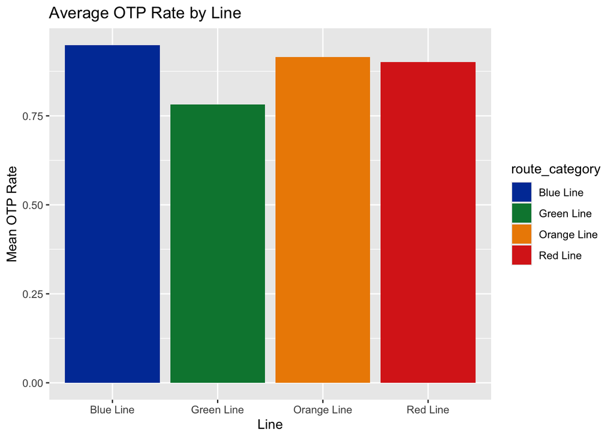

```r
cleaned_rapid %>%
  group_by(route_category) %>%
  summarise(mean_otp = mean(otp_rate)) %>%
  ggplot(aes(x = route_category, y = mean_otp, fill = route_category)) +
  geom_col() +
  scale_fill_manual(values = c("Blue Line" = "#003DA5","Green Line" = "#00843D","Orange Line" = "#ED8B00","Red Line" = "#DA291C"))+
  labs(title = "Average OTP Rate by Line", x = "Line", y = "Mean OTP Rate")
```

## OTP rate by year (2016-2024)

Looking at OTP over time reveals which years were the best and worst for each line. The Blue and Green Line peaked in 2021. There is also a dip for all transit lines in 2022, which makes me wonder what could have affected the OTP rate.

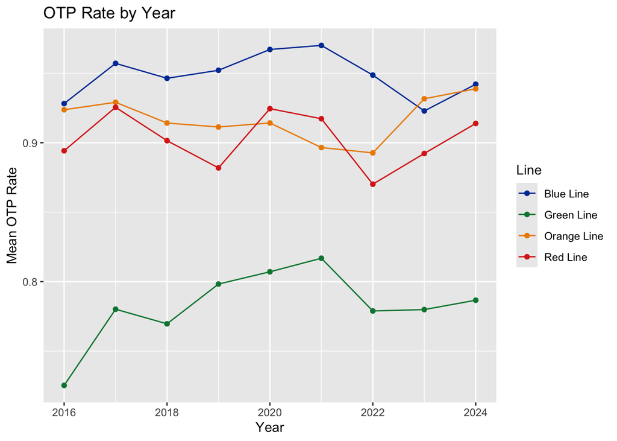

```r
cleaned_rapid %>%
  group_by(year, route_category) %>%
  summarise(mean_otp = mean(otp_rate)) %>%
  ggplot(aes(x = year, y = mean_otp, color = route_category)) +
  geom_line() +
  geom_point() +
  scale_color_manual(values = c("Blue Line" = "#003DA5","Green Line" = "#00843D","Orange Line" = "#ED8B00","Red Line" = "#DA291C"))+
  labs(title = "OTP Rate by Year", x = "Year", y = "Mean OTP Rate", color = "Line")
```

## On Time Performance by peak/off peak

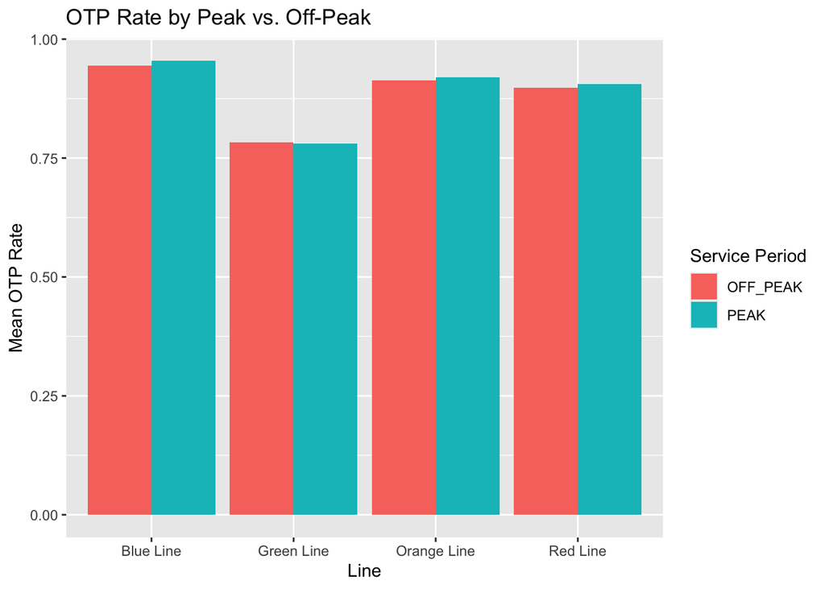

```r
cleaned_rapid %>%
  group_by(route_category, peak_offpeak_ind) %>%
  summarise(mean_otp = mean(otp_rate), .groups = "drop") %>%
  ggplot(aes(x = route_category, y = mean_otp, fill = peak_offpeak_ind)) +
  geom_col(position = "dodge") +
  labs(title = "OTP Rate by Peak vs. Off-Peak", x = "Line", y = "Mean OTP Rate", fill = "Service Period")
```

# Modeling/Analysis

## Preparing the Model data

Before modeling, preparing the data is crucial. route_category and peak_offpeak_ind need to be converted to factors so they can be seen as categorical variables instead of characters.

```r
#change variables to factors
model_data = cleaned_rapid %>%
  mutate(
    route_category = as.factor(route_category),
    peak_offpeak_ind = as.factor(peak_offpeak_ind)
    )
```

## Train/Test Split

Split the data 80/20 into training and testing sets.

```r
set.seed(1234)
train_indexes <- as.vector(createDataPartition(model_data$otp_rate, p = 0.8, list = FALSE))
mbta_train <- model_data[train_indexes,]
mbta_test <- model_data[-train_indexes,]
```

## Model 1: Linear Regression

```r
# Build the model
model_fit = lm(otp_rate ~ route_category + peak_offpeak_ind+ year, data = mbta_train)
# Summarize the model
summary(model_fit)
```

```
##
## Call:
## lm(formula = otp_rate ~ route_category + peak_offpeak_ind + year,
##     data = mbta_train)
##
## Residuals:
##      Min       1Q   Median       3Q      Max
## -0.74666 -0.02173  0.00925  0.03288  0.21009
##
## Coefficients:
##                             Estimate Std. Error  t value Pr(>|t|)
## (Intercept)               -4.6535448  0.2627806  -17.709  < 2e-16 ***
## route_categoryGreen Line  -0.1661451  0.0009318 -178.304  < 2e-16 ***
## route_categoryOrange Line -0.0326864  0.0011791  -27.720  < 2e-16 ***
## route_categoryRed Line    -0.0469108  0.0011781  -39.818  < 2e-16 ***
## peak_offpeak_indPEAK       0.0021774  0.0006407    3.398 0.000679 ***
## year                       0.0027732  0.0001301   21.315  < 2e-16 ***
## ---
## Signif. codes:  0 '***' 0.001 '**' 0.01 '*' 0.05 '.' 0.1 ' ' 1
##
## Residual standard error: 0.05401 on 29248 degrees of freedom
## Multiple R-squared:  0.6311, Adjusted R-squared:  0.6311
## F-statistic: 1.001e+04 on 5 and 29248 DF,  p-value: < 2.2e-16
```

```r
# Make predictions
predictions <- model_fit %>% predict(mbta_test)

#RMSE
RMSE(predictions, mbta_test$otp_rate)
```

```
## [1] 0.05486905
```

```r
#R-square
R2(predictions, mbta_test$otp_rate)
```

```
## [1] 0.6260156
```

- Every variable *** meaning that all predictors are highly significant.
- RMSE: 0.05486905
- R^2 = 0.6260156 which is a good fit because the closer to 1 (100%) the better the model fit.

## Model 2: Regression Tree

```r
#fit regression tree
cv_control = trainControl(
  method = "cv",
  number = 10,
  savePredictions = "final"
)
tunegrid <- data.frame(cp = seq(0.001, 0.05, by = 0.005))
```

## Kfold cross validation

```r
cv_model = train(
  otp_rate ~ route_category + peak_offpeak_ind + year,
  data = mbta_train,
  method = "rpart",
  trControl = cv_control,
  metric = "RMSE",
  tuneGrid = tunegrid
)
```

## Plot the tuning results & select best parameter value

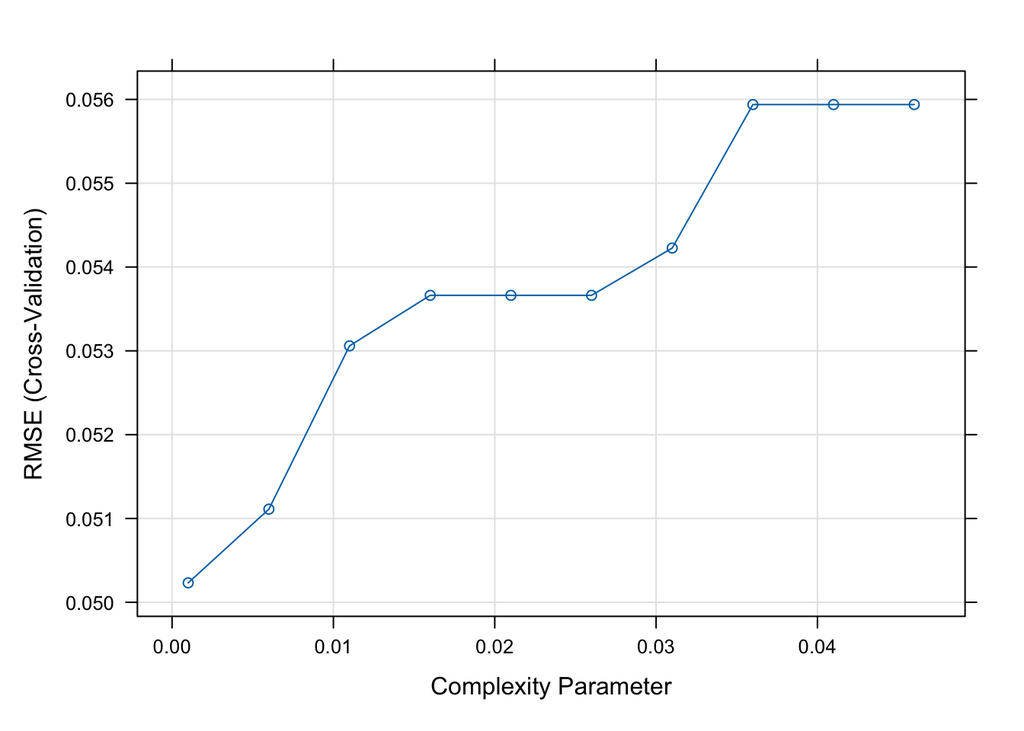

```r
 #Plot the RMSE vs. CV value
plot(cv_model)
```

```r
#grab the best cp value
cv_model$bestTune
```

```
##      cp
## 1 0.001
```

best cp value = 0.001

## Plot: Final Models Tree

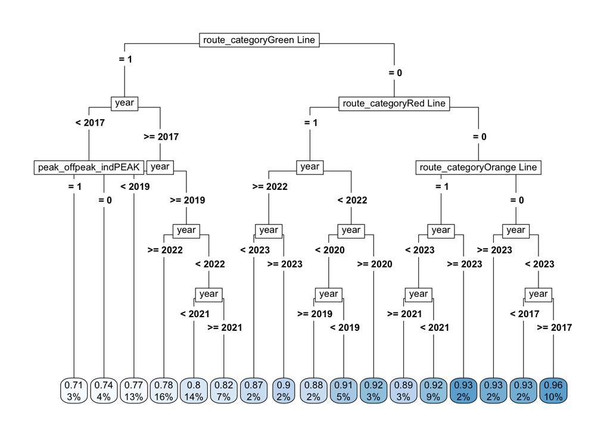

```r
rpart.plot(
  cv_model$finalModel,
  type = 5,
  box.palette = "auto"
)
```

This is a large tree; it is far too messy and unnecessary to have all these branches. It makes it hard to read.

## Fit Maxdepth (3-5)

```r
# Maxdepth = 3
model_depth3 <- train(
otp_rate ~ route_category + peak_offpeak_ind + year,
data = mbta_train,
method = "rpart",
trControl = cv_control,
metric = "RMSE",
tuneGrid = tunegrid,
control = rpart.control(maxdepth = 3)
)
# Maxdepth = 4
model_depth4 <- train(
otp_rate ~ route_category + peak_offpeak_ind + year,
data = mbta_train,
method = "rpart",
trControl = cv_control,
metric = "RMSE",
tuneGrid = tunegrid,
control = rpart.control(maxdepth = 4)
)
# Maxdepth = 5
model_depth5 <- train(
otp_rate ~ route_category + peak_offpeak_ind + year,
data = mbta_train,
method = "rpart",
trControl = cv_control,
metric = "RMSE",
tuneGrid = tunegrid,
control = rpart.control(maxdepth = 5)
)

best_RMSE = c(
  depth3 = min(model_depth3$results$RMSE),
  depth4 = min(model_depth4$results$RMSE),
  depth5 = min(model_depth5$results$RMSE)
)
best_RMSE
```

```
##     depth3     depth4     depth5
## 0.05145636 0.05059791 0.05019910
```

depth5 has a better model because it has a lower RMSE. However, since there is barely a difference depending on depth, I selected depth3 because it is not worth having a large tree.

##Plot Tree: Best Depth

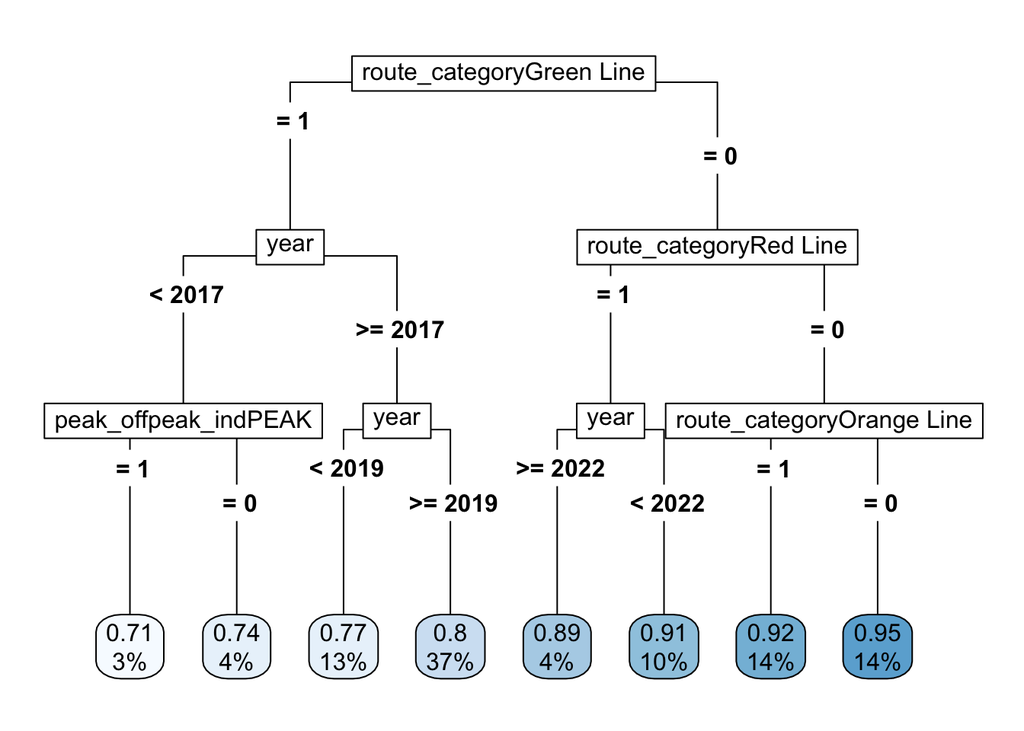

```r
final_model = model_depth3
rpart.plot(final_model$finalModel, type = 5, box.palette = "auto")
```

This tree is far better; it is smaller, easier to read, and contains useful information. Let’s say we want to find the OTP of the green line in 2019. Starting at the top, our first move is to move towards 1,(1=True/0=false), then we see the year, we move to >= 2017 because 2019 is greater. We are back to the year again, and we choose >=2019. Meaning that the green line in 2019 is reliable 80%, and it is somewhat confident with that result based on the gradient of the node.

```r
# predictions from the test dataset
pred_tree <- predict(final_model, newdata = mbta_test)

# R^2
cor(pred_tree, mbta_test$otp_rate)^2
```

```
## [1] 0.6601657
```

```r
# RMSE
library(Metrics)
predictions <- predict(final_model, newdata = mbta_test)
rmse(actual = mbta_test$otp_rate, predicted = predictions)
```

```
## [1] 0.05230279
```

**Linear Regression:**

- R^2 = 63%
- RMSE: 0.05486905

**Regression Tree:**

- R^2: 66%
- RMSE: 0.05230279

The model with the lower RMSE and higher R^2 on the test set is the better fit for predicting MBTA reliability. The regression tree fits that requirement, meaning that it is a stronger model than the linear regression model.

# Conclusion

## Model

The regression tree model R^2 = 66% explains the variation in OTP; it is a good fit for a real-world transit system. With only three predictors (line, peak/off peak, and year), the model captures an accurate view of reliability.

## Limitations

- I wish that there were more predictors for this dataset. I believe that there are other factors that can affect the reliability of rapid transit, such as weather/season, rider count, and incidents.
- They didn’t include peek/off peek for weekends; the dataset only included them for weekdays.
- The data years are somewhat dated (2016-2024). It would have been interesting to see what 2025 looked like in reliability.
- I also wish that there were some context for major dips in data, for example, what happened in 2022.

## Future

For the future, I would possibly use this dataset to analyze other forms of transportation, such as buses and commuter rail. It would be interesting at the end to combine all these analyses and see what form of transit type is the most reliable. Being transparent in this information is really amazing, as it allows the user to be able to apply this information to the real line and for the MBTA to see what they can improve on and what actions to take to keep reliability high.

# Source

[MBTA Blog](https://www.opmidatablog.com/latest-posts/the-mbtas-2024-service-delivery-policy-changing-how-success-is-measured)

[Linear Regression RMSE](https://www.sthda.com/english/articles/40-regression-analysis/165-linear-regression-essentials-in-r/)